### NOAA severe weather events analysis

# Synopsis

Using this dataset provided by National Oceanic and Atmospheric Administration’s (NOAA) we will try to answer two basic questions:

1. Across the United States, which types of events (as indicated in the EVTYPE variable) are most harmful with respect to population health?
2. Across the United States, which types of events have the greatest economic consequences?

# Data Processing

```r
    data <- read.csv("repdata-data-StormData.csv.bz2")
    relevantData <- data[,c(8, 23:28)]
    rm(data)
    nrow(relevantData) - sum(complete.cases(relevantData))
```

```
## [1] 0
```

There are no missing values in selected columns, so we do non need to impute data.

```r
    library(dplyr)
    str(relevantData)
```

```
## 'data.frame':    902297 obs. of  7 variables:
##  $ EVTYPE    : Factor w/ 985 levels "   HIGH SURF ADVISORY",..: 834 834 834 834 834 834 834 834 834 834 ...
##  $ FATALITIES: num  0 0 0 0 0 0 0 0 1 0 ...
##  $ INJURIES  : num  15 0 2 2 2 6 1 0 14 0 ...
##  $ PROPDMG   : num  25 2.5 25 2.5 2.5 2.5 2.5 2.5 25 25 ...
##  $ PROPDMGEXP: Factor w/ 19 levels "","-","?","+",..: 17 17 17 17 17 17 17 17 17 17 ...
##  $ CROPDMG   : num  0 0 0 0 0 0 0 0 0 0 ...
##  $ CROPDMGEXP: Factor w/ 9 levels "","?","0","2",..: 1 1 1 1 1 1 1 1 1 1 ...
```

```r
    head(relevantData)
```

```
##    EVTYPE FATALITIES INJURIES PROPDMG PROPDMGEXP CROPDMG CROPDMGEXP
## 1 TORNADO          0       15    25.0          K       0
## 2 TORNADO          0        0     2.5          K       0
## 3 TORNADO          0        2    25.0          K       0
## 4 TORNADO          0        2     2.5          K       0
## 5 TORNADO          0        2     2.5          K       0
## 6 TORNADO          0        6     2.5          K       0
```

First of all we will answer the question about population health. The data is grouped by event type then the sum of all fatalities and injures in each group is calculated.

```r
    populationDamage <- summarize(group_by(relevantData, EVTYPE), fatalities = sum(FATALITIES), injuries = sum(INJURIES), totalPopulationDamage = fatalities + injuries)
    topTenFatalities <- head(arrange(populationDamage, desc(fatalities)), 10)
    topTenFatalities
```

```
## Source: local data frame [10 x 4]
##
##            EVTYPE fatalities injuries totalPopulationDamage
##            (fctr)      (dbl)    (dbl)                 (dbl)
## 1         TORNADO       5633    91346                 96979
## 2  EXCESSIVE HEAT       1903     6525                  8428
## 3     FLASH FLOOD        978     1777                  2755
## 4            HEAT        937     2100                  3037
## 5       LIGHTNING        816     5230                  6046
## 6       TSTM WIND        504     6957                  7461
## 7           FLOOD        470     6789                  7259
## 8     RIP CURRENT        368      232                   600
## 9       HIGH WIND        248     1137                  1385
## 10      AVALANCHE        224      170                   394
```

In this table we can see the data about top ten most falat events. To visualize the data we will use barplot of selected ten events.

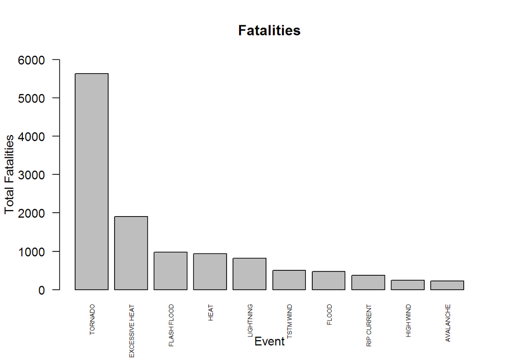

```r
    barplot(topTenFatalities$fatalities, names.arg = topTenFatalities$EVTYPE, cex.names = 0.5, las = 2, main = "Fatalities", xlab = "Event", ylab = "Total Fatalities", ylim = c(0, 6000))
```

To answer the second question we need to calculate total economic damage. We should not forget to use miltipliers in extra columns where “B” stays for billion, “M” for million, “K” for thousand.

```r
    relevantData[which(relevantData$PROPDMGEXP == "B" | relevantData$PROPDMGEXP == "b"),]$PROPDMG <- relevantData[which(relevantData$PROPDMGEXP == "B" | relevantData$PROPDMGEXP == "b"),]$PROPDMG * 1000000000
    relevantData[which(relevantData$PROPDMGEXP == "M" | relevantData$PROPDMGEXP == "m"),]$PROPDMG <- relevantData[which(relevantData$PROPDMGEXP == "M" | relevantData$PROPDMGEXP == "m"),]$PROPDMG * 1000000
    relevantData[which(relevantData$PROPDMGEXP == "K" | relevantData$PROPDMGEXP == "k"),]$PROPDMG <- relevantData[which(relevantData$PROPDMGEXP == "K" | relevantData$PROPDMGEXP == "k"),]$PROPDMG * 1000
    relevantData[which(relevantData$CROPDMGEXP == "B" | relevantData$CROPDMGEXP == "b"),]$CROPDMG <- relevantData[which(relevantData$CROPDMGEXP == "B" | relevantData$CROPDMGEXP == "b"),]$CROPDMG * 1000000000
    relevantData[which(relevantData$CROPDMGEXP == "M" | relevantData$CROPDMGEXP == "m"),]$CROPDMG <- relevantData[which(relevantData$CROPDMGEXP == "M" | relevantData$CROPDMGEXP == "m"),]$CROPDMG * 1000000
    relevantData[which(relevantData$CROPDMGEXP == "K" | relevantData$CROPDMGEXP == "k"),]$CROPDMG <- relevantData[which(relevantData$CROPDMGEXP == "K" | relevantData$CROPDMGEXP == "k"),]$CROPDMG * 1000
    economicDamage <- summarize(group_by(relevantData, EVTYPE), propDamage = sum(PROPDMG), cropDamage = sum(CROPDMG), totaleconomicDamage = propDamage + cropDamage)
    topTenEconomicDamage <- head(arrange(economicDamage, desc(totaleconomicDamage)), 10)
    topTenEconomicDamage
```

```
## Source: local data frame [10 x 4]
##
##               EVTYPE   propDamage  cropDamage totaleconomicDamage
##               (fctr)        (dbl)       (dbl)               (dbl)
## 1              FLOOD 144657709807  5661968450        150319678257
## 2  HURRICANE/TYPHOON  69305840000  2607872800         71913712800
## 3            TORNADO  56937160779   414953270         57352114049
## 4        STORM SURGE  43323536000        5000         43323541000
## 5               HAIL  15732267048  3025954473         18758221521
## 6        FLASH FLOOD  16140812067  1421317100         17562129167
## 7            DROUGHT   1046106000 13972566000         15018672000
## 8          HURRICANE  11868319010  2741910000         14610229010
## 9        RIVER FLOOD   5118945500  5029459000         10148404500
## 10         ICE STORM   3944927860  5022113500          8967041360
```

Let’s visualize the data.

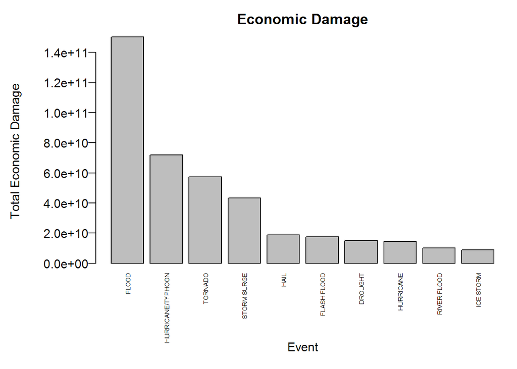

```r
    par(mar = c(7.0, 6.5, 2.5, 0.5), mgp = c(5, 0.5, 0))
    barplot(topTenEconomicDamage$totaleconomicDamage, names.arg = topTenEconomicDamage$EVTYPE, cex.names = 0.5, las = 2, main = "Economic Damage", xlab = "Event", ylab = "Total Economic Damage")
```

Here we can see that floods are the most damaging events to country’s economy.

### Results

The analysis have shown that tornadoes are the most fatal weather events due to the highest amount of fatalities. We also found out that floods are the most harmful events from the economic side.